# Assignment 3 - Text Mining

## Text Mining

On the course Github, navigate to the page for dataset `pubmed` (https://github.com/dmcable/BIOSTAT620W26/tree/main/data/pubmed) and download the `pubmed.csv` dataset. This dataset contains 3,241 abstracts from articles collected via 5 PubMed searches. The search terms are listed in the second column, `term` and these will serve as the “documents.” Your job is to analyze these abstracts to find interesting insights.

1. (15 points) How many abstracts are associated with each search term? Tokenize the abstracts and count the number of each token. Do you see anything interesting? What are the 5 most common tokens for each search term?

```r
library(readr)
library(dplyr)
library(tidytext)
library(tidyr)
library(ggplot2)

# Load the dataset
url <- "https://raw.githubusercontent.com/dmcable/BIOSTAT620W26/main/data/pubmed/pubmed.csv"
pubmed <- read_csv(url)
# 1. How many abstracts are associated with each search term?
abstract_counts <- pubmed %>%
  count(term, name = "number_of_abstracts") %>%
  arrange(desc(number_of_abstracts))

print("Abstracts per search term:")
```

```
[1] "Abstracts per search term:"
```

```r
print(abstract_counts)
```

```
# A tibble: 5 × 2
  term            number_of_abstracts
  <chr>                         <int>
1 covid                           981
2 prostate cancer                 787
3 preeclampsia                    780
4 cystic fibrosis                 376
5 meningitis                      317
```

```r
# 2. Tokenize the abstracts and count the number of each token
tokens_all <- pubmed %>%
  unnest_tokens(word, abstract)

# Overall token counts
token_counts <- tokens_all %>%
  count(word, sort = TRUE)

print(head(token_counts, 10))
```

```
# A tibble: 10 × 2
   word      n
   <chr> <int>
 1 the   28126
 2 of    24760
 3 and   19993
 4 in    14653
 5 to    10920
 6 a      8245
 7 with   8038
 8 covid  7275
 9 19     7080
10 is     5649
```

```r
# 3. What are the 5 most common tokens for each search term? (With stop words)
top_5_tokens_per_term <- tokens_all %>%
  group_by(term) %>%
  count(word, sort = TRUE) %>%
  slice_max(n, n = 5, with_ties = FALSE) %>%
  ungroup()

print("Top 5 tokens per term:")
```

```
[1] "Top 5 tokens per term:"
```

```r
print(top_5_tokens_per_term)
```

```
# A tibble: 25 × 3
   term            word      n
   <chr>           <chr> <int>
 1 covid           the    9741
 2 covid           of     7668
 3 covid           covid  7275
 4 covid           19     7035
 5 covid           and    6861
 6 cystic fibrosis the    2677
 7 cystic fibrosis of     2304
 8 cystic fibrosis and    1777
 9 cystic fibrosis in     1497
10 cystic fibrosis to     1011
# ℹ 15 more rows
```

Ans: Abstracts per search term with counts are as above. I found there are some stop words. Top 5 tokens per term are also as above.

2. (15 points) Does removing stop words change what tokens appear as the most frequent? What are the 5 most common tokens for each search term after removing stop words?

```r
# remove stop words
tokens_cleaned <- pubmed %>%
  unnest_tokens(word, abstract) %>%
  anti_join(stop_words, by = "word")

# Find the 5 most common tokens for each search term
top_5_cleaned <- tokens_cleaned %>%
  group_by(term) %>%
  count(word, sort = TRUE) %>%
  slice_max(n, n = 5, with_ties = FALSE) %>%
  ungroup()

print("Top 5 tokens per term (removing stop words):")
```

```
[1] "Top 5 tokens per term (removing stop words):"
```

```r
print(top_5_cleaned)
```

```
# A tibble: 25 × 3
   term            word         n
   <chr>           <chr>    <int>
 1 covid           covid     7275
 2 covid           19        7035
 3 covid           patients  2293
 4 covid           disease    943
 5 covid           pandemic   800
 6 cystic fibrosis fibrosis   867
 7 cystic fibrosis cystic     862
 8 cystic fibrosis cf         625
 9 cystic fibrosis patients   586
10 cystic fibrosis disease    400
# ℹ 15 more rows
```

Ans: Yes, it changed what tokens appear as the most frequent. The 5 most common tokens for each search term after removing stop words are as above.

3. (15 points) Tokenize the abstracts into bigrams. Find the 10 most common bigrams and visualize them.

```r
# Load stop words from tidytext
data("stop_words")

# Tokenize abstracts into bigrams
pubmed_bigrams <- pubmed %>%
  unnest_tokens(bigram, abstract, token = "ngrams", n = 2)

# Separate the bigrams, filter out stop words, and recount
bigram_counts <- pubmed_bigrams %>%
  separate(bigram, c("word1", "word2"), sep = " ") %>%

  filter(!word1 %in% stop_words$word) %>%
  filter(!word2 %in% stop_words$word) %>%

  filter(!is.na(word1) & !is.na(word2)) %>%

  count(word1, word2, sort = TRUE) %>%

  unite(bigram, word1, word2, sep = " ")

# Extract the top 10 most common bigrams
top_10_bigrams <- bigram_counts %>%
  slice_max(n, n = 10, with_ties = FALSE)

print(top_10_bigrams)
```

```
# A tibble: 10 × 2
   bigram                  n
   <chr>               <int>
 1 covid 19             6969
 2 prostate cancer      3222
 3 pre eclampsia        1854
 4 cystic fibrosis       860
 5 19 patients           447
 6 19 pandemic           419
 7 coronavirus disease   361
 8 95 ci                 322
 9 sars cov              317
10 cov 2                 299
```

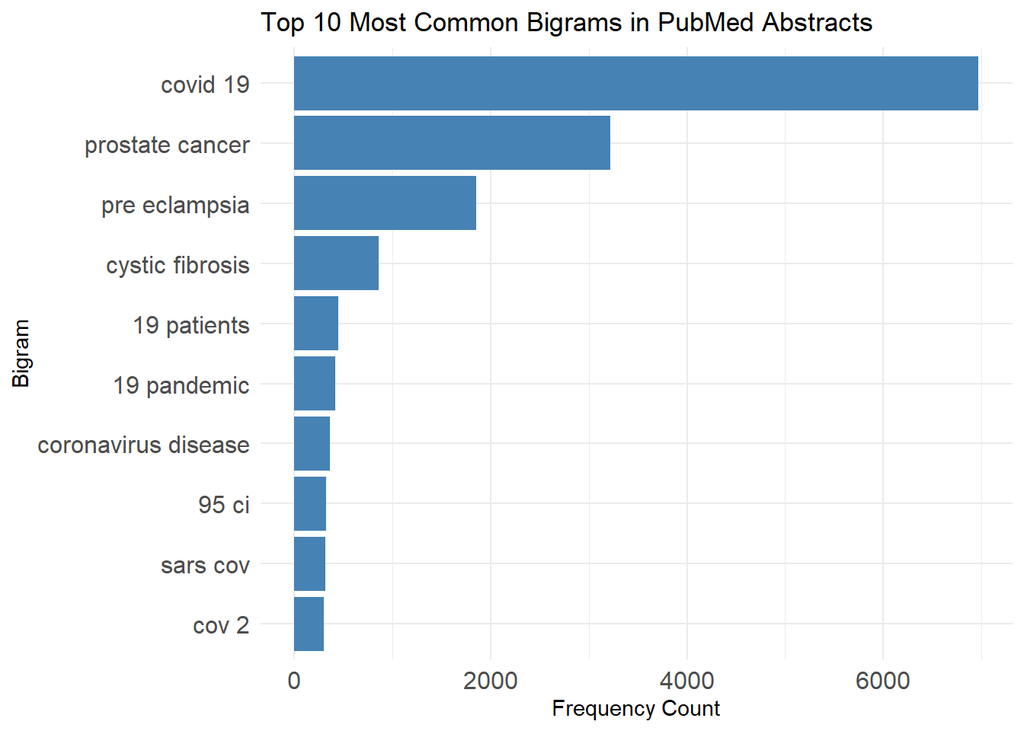

```r
# Visualize the top 10 bigrams
ggplot(top_10_bigrams, aes(x = reorder(bigram, n), y = n)) +
  geom_col(fill = "steelblue") +
  coord_flip() +
  labs(
    title = "Top 10 Most Common Bigrams in PubMed Abstracts",
    x = "Bigram",
    y = "Frequency Count"
  ) +
  theme_minimal() +
  theme(axis.text = element_text(size = 12))
```

4. (15 points) Calculate the TF-IDF value for each word-search term combination (here you want the search term to be the “document”). What are the 5 tokens from each search term with the highest TF-IDF value? How are the results different from the answers you got in Question 1?

```r
# Tokenize the text
tokens_all <- pubmed %>%
  unnest_tokens(word, abstract)

# Count the frequency of each word per search term (document)
word_counts <- tokens_all %>%
  count(term, word, sort = TRUE)

# Calculate TF-IDF
tfidf_data <- word_counts %>%
  bind_tf_idf(word, term, n)

# Find the top 5 tokens with the highest TF-IDF for each search term
top_5_tfidf <- tfidf_data %>%
  group_by(term) %>%
  slice_max(tf_idf, n = 5, with_ties = FALSE) %>%
  ungroup() %>%
  arrange(term, desc(tf_idf))

print("Top 5 tokens per term with the highest TF-IDF value:")
```

```
[1] "Top 5 tokens per term with the highest TF-IDF value:"
```

```r
print(top_5_tfidf %>% select(term, word, tf_idf, n))
```

```
# A tibble: 25 × 4
   term            word         tf_idf     n
   <chr>           <chr>         <dbl> <int>
 1 covid           covid       0.0597   7275
 2 covid           pandemic    0.00657   800
 3 covid           coronavirus 0.00531   647
 4 covid           sars        0.00305   372
 5 covid           cov         0.00274   334
 6 cystic fibrosis cf          0.0117    625
 7 cystic fibrosis fibrosis    0.00901   867
 8 cystic fibrosis cystic      0.00896   862
 9 cystic fibrosis cftr        0.00282    86
10 cystic fibrosis sweat       0.00272    83
# ℹ 15 more rows
```

Ans: The 5 tokens from each search term with the highest TF-IDF value are as above. The results from question 4 did not have stop words, whereas answers from question 1 had stop words. Additionally, general medical words (like “patients” or “disease”) that might have had high frequencies in question 1 are penalized by TF-IDF because they appear across all the different disease abstracts.

## Sentiment Analysis

5. (20 points) Perform a sentiment analysis using the NRC lexicon. What is the most common sentiment for each search term? What if you remove `"positive"` and `"negative"` from the list?

```r
# install.packages("textdata")
library(textdata)

tokens <- pubmed %>%
  unnest_tokens(word, abstract)

# Get the NRC sentiment lexicon
nrc_lexicon <- get_sentiments("nrc")

# Join tokens with the NRC lexicon and count sentiments per search term
sentiment_counts <- tokens %>%
  inner_join(nrc_lexicon, by = "word", relationship = "many-to-many") %>%
  count(term, sentiment, sort = TRUE)

# What is the most common sentiment for each search term?
top_sentiment_overall <- sentiment_counts %>%
  group_by(term) %>%
  slice_max(n, n = 1, with_ties = FALSE) %>%
  ungroup()

print("Most common sentiment for each search term:")
```

```
[1] "Most common sentiment for each search term:"
```

```r
print(top_sentiment_overall)
```

```
# A tibble: 5 × 3
  term            sentiment     n
  <chr>           <chr>     <int>
1 covid           positive   9874
2 cystic fibrosis positive   2747
3 meningitis      negative   2111
4 preeclampsia    positive   8014
5 prostate cancer negative   8918
```

```r
# What if you remove "positive" and "negative"?
top_sentiment_specific <- sentiment_counts %>%
  filter(!sentiment %in% c("positive", "negative")) %>%
  group_by(term) %>%
  slice_max(n, n = 1, with_ties = FALSE) %>%
  ungroup()

print("Most common sentiment removing positive/negative:")
```

```
[1] "Most common sentiment removing positive/negative:"
```

```r
print(top_sentiment_specific)
```

```
# A tibble: 5 × 3
  term            sentiment        n
  <chr>           <chr>        <int>
1 covid           fear          7730
2 cystic fibrosis disgust       1714
3 meningitis      fear          1510
4 preeclampsia    anticipation  4780
5 prostate cancer fear          8118
```

Ans: The most common sentiments for each search term are as above.

6. (20 points) Now perform a sentiment analysis using the AFINN lexicon to get an average positivity score for each abstract (hint: you may want to create a variable that indexes, or counts, the abstracts). Create a visualization that shows these scores grouped by search term. Are any search terms noticeably different from the others?

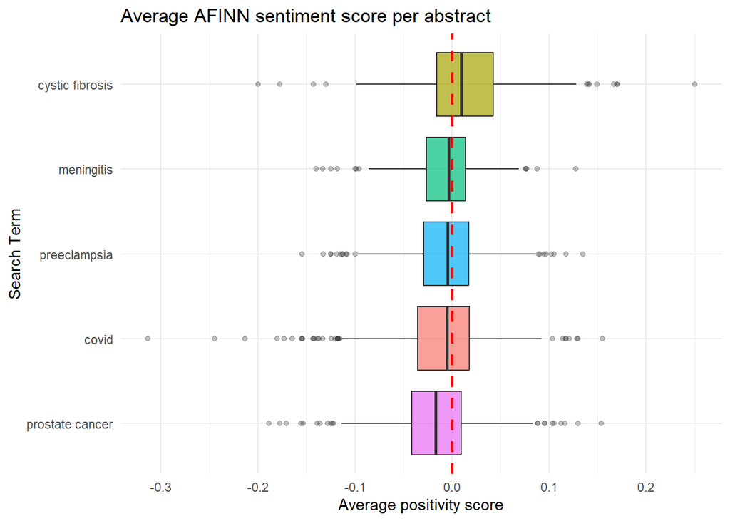

```r
afinn_lexicon <- get_sentiments("afinn")

abstract_sentiment <- pubmed %>%
  mutate(abstract_id = row_number()) %>%
  unnest_tokens(word, abstract) %>%
  left_join(afinn_lexicon, by = "word") %>%
  mutate(value = replace_na(value, 0)) %>%
  group_by(term, abstract_id) %>%
  summarize(mean_score = mean(value), .groups = "drop")

ggplot(abstract_sentiment, aes(x = reorder(term, mean_score, FUN = median), y = mean_score, fill = term)) +
  geom_boxplot(alpha = 0.7, outlier.alpha = 0.3) +
  geom_hline(yintercept = 0, linetype = "dashed", color = "red", size = 1) +
  coord_flip() +
  labs(
    title = "Average AFINN sentiment score per abstract",
    x = "Search Term",
    y = "Average positivity score"
  ) +
  theme_minimal() +
  theme(legend.position = "none")
```

Ans: No search term is noticeably different, but cystic fibrosis is more positive and prostate cancermore negative in this data.